# Exploratory Data analysis R

12th July 2024

## Session objectives

1. Compute and interpret Pearson’s r between two variables.

2. Set-up a simple linear regression model.

3. Conduct and interpret a chi-square test.

## Data

- We will use data from the World Happiness Report.
- The csv file (WHR2018.csv) has been provided.

## Linear Regression

## Scatter with *happiness!*

What is the relationship between *Confidence in national government* and *Freedom to make life choices?*

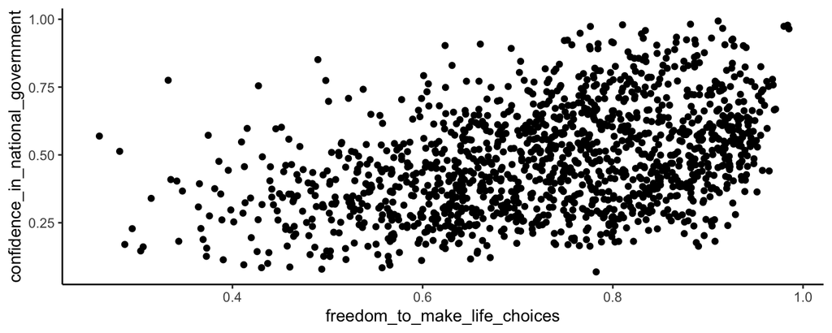

```r
# import the happy dataset
happy <- import("../data/WHR2018.csv") %>%
  clean_names()

# plot the scatter plot
ggplot(happy, aes(x=freedom_to_make_life_choices,
                     y=confidence_in_national_government))+
  geom_point()+
  theme_classic()
```

## Scatter with *happiness!* - multiple facets

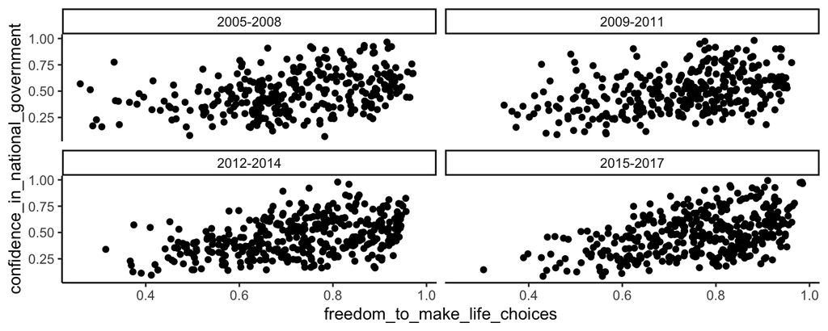

```r
# plot the scatter plot
ggplot(happy, aes(x=freedom_to_make_life_choices,
                     y=confidence_in_national_government)) +
  geom_point()+
  theme_classic() +
  facet_wrap(~year_grp)
```

## `cor` for correlation

Correlation between *Confidence in national government* and *Freedom to make life choices?*

```r
  cor(happy$freedom_to_make_life_choices,
      happy$confidence_in_national_government)
```

```
## [1] NA
```

This returns `NA` - why?

## `cor` for correlation

Correlation between *Confidence in national government* and *Freedom to make life choices?*

```r
happy <- happy %>%
  filter(freedom_to_make_life_choices!="",confidence_in_national_government!="" )

  cor(happy$freedom_to_make_life_choices,
      happy$confidence_in_national_government)
```

```
## [1] 0.4080963
```

## plot the line of best fit

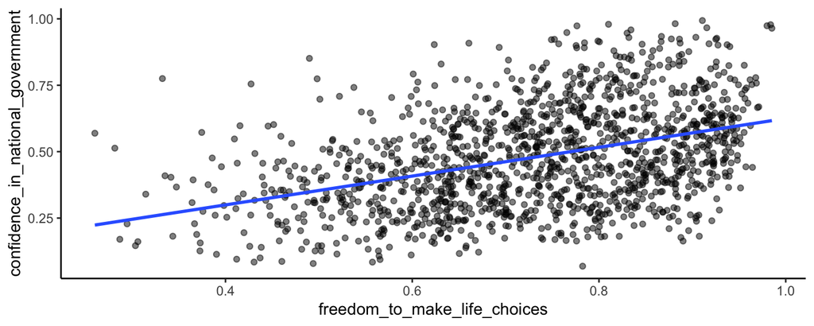

```r
ggplot(happy, aes(x=freedom_to_make_life_choices,
                       y=confidence_in_national_government)) +
  geom_point(alpha=.5) +
  geom_smooth(method=lm, se=FALSE) +
  theme_classic()
```

## Linear regression model

A **linear regression model** uses a straight line to describe the relationship between variables.

[figure not shown]

## Linear regression model

**Step 1:** Make sure your data meets the assumptions

**Linearity:** the relationship betwen the outcome and explanatory variable must be linear. Test visually scatter plot.

[figure not shown]

## Linear regression model

**Step 1:** Make sure your data meets the assumptions

**Homoscedasticity:** variance of the residuals is constant across all levels of the independent variables.

[figure not shown]

## Linear regression model

**Step 1:** Make sure your data meets the assumptions

**Normality:** The residuals, when plotted, follow a normal distribution.

[figure not shown]

## Linear regression model

**Step 1:** Make sure your data meets the assumptions

**Multicollinearity:** this is when the independent variables are highly correlated with each other. Multicollinearity can make it difficult to analyze the individual effects of the features in predicting the target

## Linear regression model

**Step 2:** Perform a linear regression analysis

- Two lines of code are needed to perform a linear regression analysis.

- The first line of code makes the linear model, and the second line prints out the summary of the model.

```r
model_1 <- lm(freedom_to_make_life_choices ~ confidence_in_national_government, data = happy)

summary(model_1)
```

## Linear regression model

```r
model_1 <- lm(freedom_to_make_life_choices ~ confidence_in_national_government, data = happy)

summary(model_1)
```

```
##
## Call:
## lm(formula = freedom_to_make_life_choices ~ confidence_in_national_government,
##     data = happy)
##
## Residuals:
##      Min       1Q   Median       3Q      Max
## -0.49912 -0.08191  0.00183  0.10498  0.26737
##
## Coefficients:
##                                   Estimate Std. Error t value Pr(>|t|)
## (Intercept)                       0.584291   0.009495   61.54   <2e-16 ***
## confidence_in_national_government 0.307186   0.018412   16.68   <2e-16 ***
## ---
## Signif. codes:  0 '***' 0.001 '**' 0.01 '*' 0.05 '.' 0.1 ' ' 1
##
## Residual standard error: 0.1309 on 1393 degrees of freedom
## Multiple R-squared:  0.1665, Adjusted R-squared:  0.1659
## F-statistic: 278.4 on 1 and 1393 DF,  p-value: < 2.2e-16
```

## Chi-square

## Chi-square

A Chi-square is used to examine whether there is an association between the row variable and the column variable.

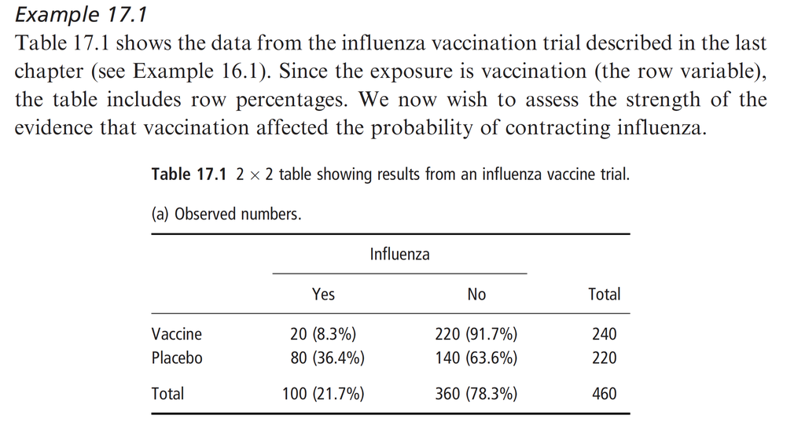

Source: Essentials of Medical Statistics (Betty R. Kirkwood)

## Chi-square test in R

Step 1:Load dataset

In this example we have created a fictional dataset

```r
# Sample data frame (replace this with your actual data)

data_summary <- data.frame(
  cough = sample(c("Yes", "No"), 100, replace = TRUE),
  gender = sample(c("Male", "Female"), 100, replace = TRUE)
)

head(data_summary)
```

```
##   cough gender
## 1    No Female
## 2    No Female
## 3    No   Male
## 4    No   Male
## 5    No Female
## 6   Yes Female
```

## Chi-square test in R

Step 2: Create a contingency table

```r
# Create the 2 by 2 table
contingency_table <- table(data_summary$cough, data_summary$gender)

contingency_table
```

```
##
##       Female Male
##   No      25   22
##   Yes     26   27
```

## Chi-square test in R

Step 3: Perform the chi-square test!

```r
contingency_table
```

```
##
##       Female Male
##   No      25   22
##   Yes     26   27
```

```r
chisq.test(contingency_table)
```

```
##
##  Pearson's Chi-squared test with Yates' continuity correction
##
## data:  contingency_table
## X-squared = 0.045124, df = 1, p-value = 0.8318
```

What does this mean?